# Thème Image - TP2 - Utilisation de l’histogramme pour la correction et le traitement d’images

```python
!jupyter nbconvert --to html TP2-2024-2025__v2.ipynb
```

- Vérifiez que vous vous trouvez bien dans le dossier de travail pour ce TP
- Si ça n'est pas le cas, pour y accèder utilisez les commandes `pwd` (print working directory), `cd` (change directory) et `ls`(list contents) pour naviguer sur le disque.
- Changez de repertoire jusqu'a voir tous les fichiers necessaires au TP.
- Importez les modules dont vous aurez besoin en exécutant la cellule suivante (`Ctrl+Enter`).
- Familiarisez vous avec les fonctions mises à votre disposition dans le fichier `utils.py`; elles vous seront utiles pour la suite!

```python
import numpy as np
import matplotlib.pyplot as plt
from copy import copy
from utils import *

test_utils()
plt.ion()
plt.rcParams['image.cmap'] = 'gray'
#%matplotlib widget
```

```
Test utils ok
```

## Histogramme et histogramme cumulé

### Histogramme

Python possède des instructions (dans la librairie `numpy`; voir le fichier `utils.py`) permettant de calculer automatiquement l'histogramme d'une image. Utiliser ces fonctions revient à utiliser une "boîte noire" dont on ne connaît pas le fonctionnement interne.

Nous utiliserons des boîtes noires plus tard afin de gagner du temps (et parce que leur implémentation est souvent très optimisée), mais nous allons aussi re-coder certains algorithmes (en "boîtes blanches") afin de bien en comprendre le fonctionnement.

Nous pourrons alors comparer les résultats produits par une boîte noire à ceux produits par notre boîte blanche, afin de vérifier que notre implémentation est correcte.

#### Exercice 1 : Tracés d'histogrammes

Dans le cas des images, nous voulons compter le nombre de pixels dont la valeur est $p$, $\forall p \in \lbrace 0,\ldots,255\rbrace$.

Affichez les images suivantes et tracez leurs histogrammes :

`papillon.bmp`, `fruits.bmp`, `manoir.bmp`, `desert.bmp`

Commentez l'aspect général des images et l'allure de leurs histogrammes.

[output not shown]

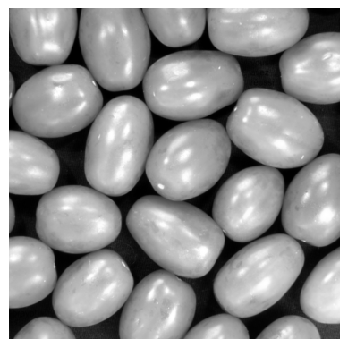

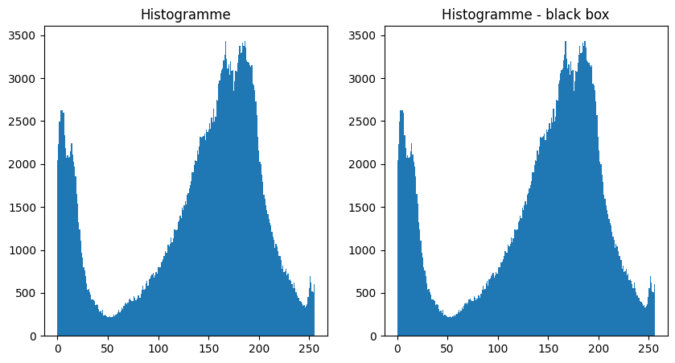

```python
# Charger et afficher l'image
img = np.array(plt.imread('./tomates.bmp'))
fig,ax = plt.subplots()
ax.imshow(img,vmin=0,vmax=255)
ax.set_axis_off()

# Compute histogram from scratch
hist = np.zeros(256)
for i in range(img.shape[0]):
    for j in range(img.shape[1]):
        hist[img[i, j]] += 1

# Show histogram
fig,ax = plt.subplots(1,2,figsize=(10,5))
ax[0].bar(range(256),hist,width=1, align='center')
ax[0].set_title('Histogramme')

# Il existe dans dans matplotlib une fonction graphique pour calculer et afficher l'histogramme en 1 ligne.
# Veillez à bien maitriser ces commandes. Elles seront très utiles dans la suite.
black_box_hist,_,_ = ax[1].hist(img.flatten(),bins=256, width=1,range=(0,256))
ax[1].set_title('Histogramme - black box')

# Comparer les resultats black box et white box
print(f'Difference entre black box et white box=\n{black_box_hist - hist}')
```

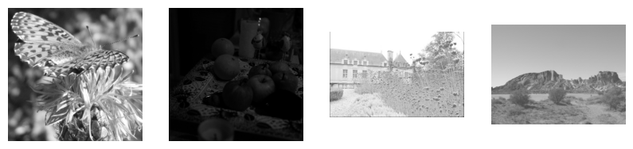

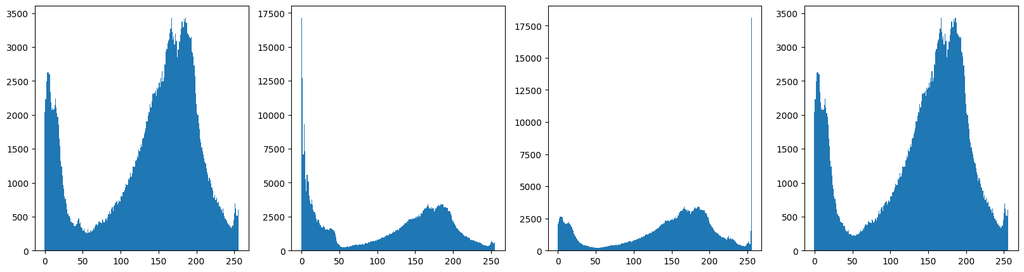

```python
#Affichage
img1 = plt.imread("papillon.bmp")
img2 = plt.imread("fruits.bmp")
img3 = plt.imread("manoir.bmp")
img4 = plt.imread("desert.bmp")
images = (img1,img2,img3,img4)

fig,ax = plt.subplots(1,4,figsize=(10,10))
for i,image in enumerate(images):
    ax[i].imshow(image,vmin=0,vmax=255)
    ax[i].set_axis_off()


# Histograme
img1 = np.array(plt.imread('./papillon.bmp'))
img2 = np.array(plt.imread('./fruits.bmp'))
img3 = np.array(plt.imread('./manoir.bmp'))
img4 = np.array(plt.imread('./desert.bmp'))

fig,ax = plt.subplots(1,4,figsize=(20,5))
for i, image in enumerate(images):
    ax[i].bar(range(256),hist,width=1, align='center')
    black_box_hist,_,_ = ax[i].hist(image.flatten(),bins=256, width=1,range=(0,256))
```

# Exercice 2

## Effet d'une transformation sur l'histogramme

On considère les fonctions de transformation suivantes :

- $f_1(p) = p + 50 $
- $f_2(p) = 0.5(p-127) + 127 $
- $f_3(p) = 2(p-127) + 127 $

Modifez le code ci-dessous pour appliquer ces transformations à quelques images.

Affichez les images transformées et leurs histogrammes, et commentez la différence par rapport à l'original.

Dans quels cas y a-t-il perte d'information par saturation des valeurs à 0 ou 255 ?

Que se passe-t-il si on évite le bloc "clip" en entrant clip = False ?

COMMENTAIRES:

Perte d’information importante pour les pixels proches de 0 ou 255 dans l’image originale, car l’étalement du contraste dépasse les limites.

𝑓1: décalage des valeurs (éclaircissement). 𝑓2: réduction du contraste. f3: augmentation du contraste. La gestion des valeurs hors plage (avec clip) est cruciale pour préserver la qualité des images.

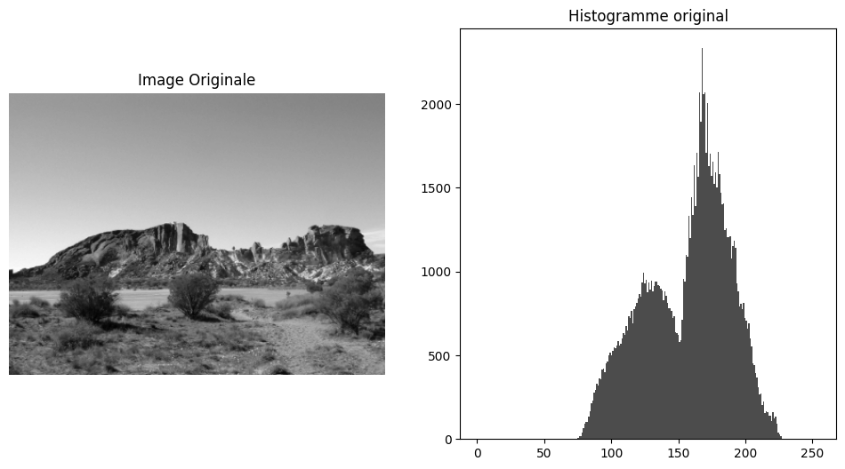

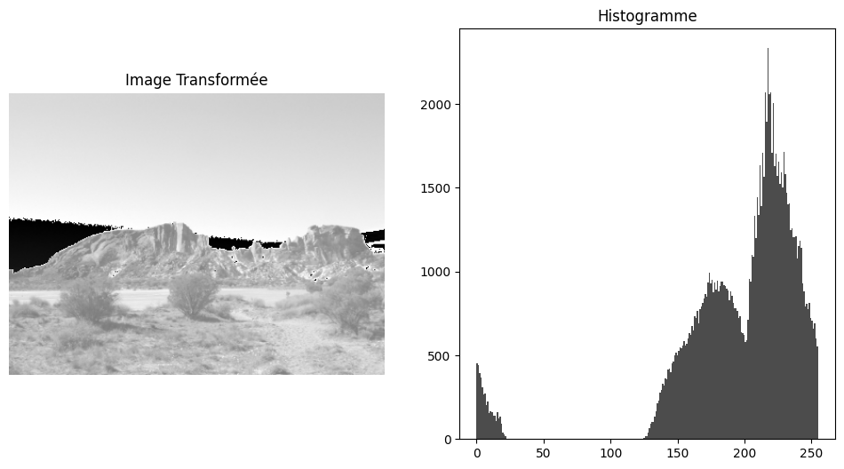

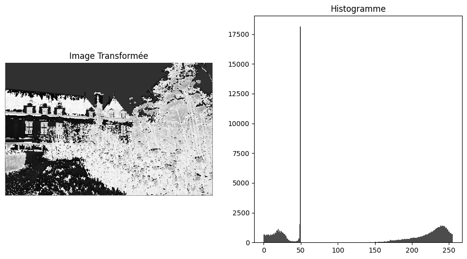

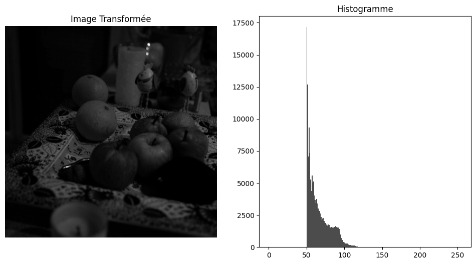

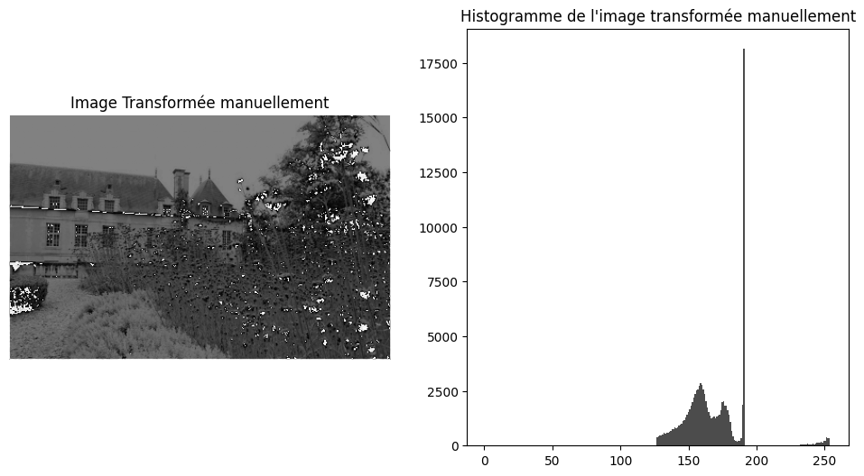

```python
def f1(p):
    return p + 50
def f2(p):
    return 0.5 * (p - 127) + 127
def f3(p):
    return 2 * (p - 127) + 127
desert = plt.imread("desert.bmp")
manoir = plt.imread("manoir.bmp")
fruits = plt.imread("fruits.bmp")
images = (desert, manoir, fruits)

def appliquer(image, transformation_func, ax):
    transformed_image = transformation_func(image)
    transformed_image = np.clip(transformed_image, 0, 255)

    ax[0].imshow(transformed_image, cmap='gray')
    ax[0].axis('off')
    ax[0].set_title("Image Transformée")

    ax[1].hist(transformed_image.ravel(), bins=256, range=(0, 255), color='black', alpha=0.7)
    ax[1].set_title("Histogramme")

fig, ax = plt.subplots(1, 2, figsize=(12, 6))

ax[0].imshow(desert, cmap='gray')
ax[0].axis('off')
ax[0].set_title("Image Originale")
# Afficher l'histogramme
ax[1].hist(desert.ravel(), bins=256, range=(0, 255), color='black', alpha=0.7)
ax[1].set_title('Histogramme original')

for image in images:
    fig, ax = plt.subplots(1, 2, figsize=(12, 6))
    appliquer(image, f1, ax)
    plt.show()

img_2 = manoir.copy()

clip = True
for i in range(img_2.shape[0]):
    for j in range(img_2.shape[1]):

        new_val = f2(img_2[i, j])


        if clip:
            if new_val > 255:
                img_2[i, j] = 255
            elif new_val < 0:
                img_2[i, j] = 0
            else:
                img_2[i, j] = new_val
        else:
            img_2[i, j] = new_val

fig, ax = plt.subplots(1, 2, figsize=(12, 6))
ax[0].imshow(img_2, cmap='gray')
ax[0].axis('off')
ax[0].set_title("Image Transformée manuellement")

ax[1].hist(img_2.ravel(), bins=256, range=(0, 255), color='black', alpha=0.7)
ax[1].set_title("Histogramme de l'image transformée manuellement")

plt.show()
```

# Exercice 3

## Histogramme cumulé

Etant donné l'histogramme $h(p)$ d'une image, l'histogramme cumulé peut être défini de deux manières.

1. Par une formule explicite $(\star) H(p) = \sum_{q = 0}^{p}h(q), \ \forall p \in\lbrace 0,\ldots, 255\rbrace.$
2. Par récurrence : $H(0) = h(0)$ et pour $p\in{1, \ldots, 255}, H(p) = H(p-1) + h(p)$.

En pratique, l'histogramme cumulé $H$ est stocké sous la forme d'un tableau à 256 entrées, comme l'histogramme $h$ que vous avez déjà calculé, il faut faire attention aux indices !

Completez la cellule ci-dessous pour qu'elle réalise le calcul de l'histogramme cumulé, puis testez votre fonction.

Quelle est la valeur du dernier élément du tableau $H$ ? A quoi correspond-elle ?

```
[2025-01-28 21:21:40.000] hist LENT: start
[2025-01-28 21:21:40.008] hist LENT: end
[2025-01-28 21:21:40.008] hist RAPIDE: start
[2025-01-28 21:21:40.008] hist RAPIDE: end
Erreur max.: 470.0
Valeur du dernier elemet de H_1: 65454.0
Valeur du dernier elemet DE H_2: 65536.0
```

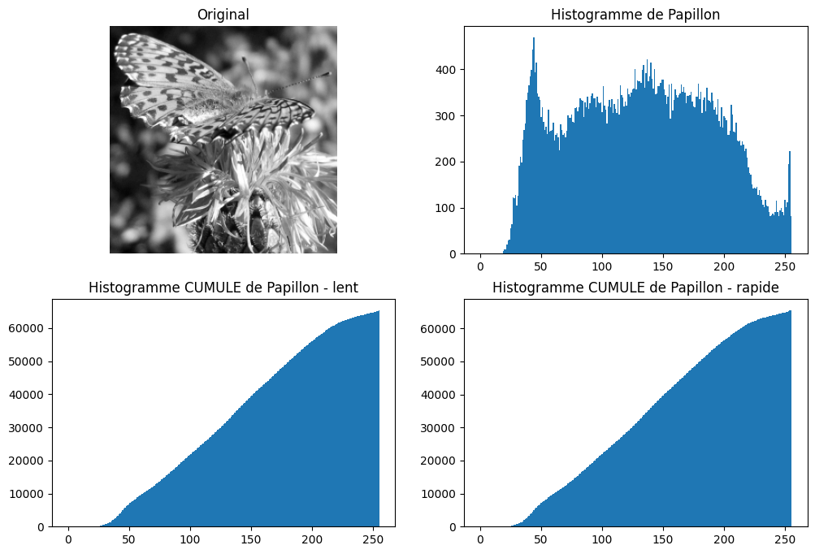

```python
# Charger et afficher l'image
img = np.array(plt.imread('./papillon.bmp'))
fig,ax = plt.subplots(2,2, figsize=(12,8))
ax[0,0].imshow(img)
ax[0,0].set_axis_off()
ax[0,0].set_title('Original')

# Calculer l'histogramme: white box (on en aura besoin plus bas)
hist = np.zeros(256)
for i in range(img.shape[0]):
    for j in range(img.shape[1]):
        hist[img[i, j]] += 1

# Afficher l'histogramme
_ = ax[0,1].bar(range(256),hist,width=1,align='center')
ax[0,1].set_title('Histogramme de Papillon')

# Histogramme cumule: calcul lent (méthode 1, lente)
print_timestamp('hist LENT: start')
H_1 = np.zeros(256)
for i in range(256):
    for j in range(i):
        H_1[i] += hist[j]
print_timestamp('hist LENT: end')

# Histogramme cumule: calcul optimise (méthode 2, optimisée)
print_timestamp('hist RAPIDE: start')
H_2 = np.zeros(256)
for i in range(256):
    H_2[i] = H_2[i-1] + hist[i]
print_timestamp('hist RAPIDE: end')

# Les deux histogrammes devraient etre identiques
print(f'Erreur max.: {np.max(np.abs(H_2 - H_1))}')

# Afficher les 2 histogrammes cumulés
ax[1,0].bar(range(256),H_1, width=1,align='center')
ax[1,0].set_title('Histogramme CUMULE de Papillon - lent')
ax[1,1].bar(range(256),H_2, width=1,align='center')
ax[1,1].set_title('Histogramme CUMULE de Papillon - rapide')

print(f"Valeur du dernier elemet de H_1: {H_1[-1]}")
print(f"Valeur du dernier elemet DE H_2: {H_2[-1]}")
```

# Exercice 4

## Histogramme et correction de contraste

Dans cette partie, nous allons voir comment l'histogramme permet de choisir la transformation affine à appliquer à une image donnée. La transformation, dite LUT (ou Look Up Table) sera affichée par la cellule ci-dessous.

L'idée est d'identifier l'intervalle $[p_0,p_1]$ de valeurs dans lequel se trouvent la majorité des pixels de l'image puis de répartir ces valeurs sur l'intervalle $[0,255]$.

Tracez l'histogramme de l'image `desert.bmp`.

- Quel est le plus petit intervalle qui contient tous les pixels ?
- Quelle est la transformation affine qui permet de répartir ces valeurs sur l'intervalle $[0,255]$ ?
- Modifiez les paramètres dans le code de la cellule ci-dessous puis appliquez la LUT 'idéale' puis quelques autres transformations à l'image.
- Commentez les différences au niveau des images et des histogrammes.

COMMENTAIRES:

Les histogrammes de la première et de la troisième image sont identiques, cependant, sur le troisième histogramme, nous avons réduit la plage des pixels. L’histogramme de l’image 2 est contrasté et présente beaucoup plus de pixels aux extrémités du graphique.

```
L'intervalle des pixels est : (np.uint8(19), np.uint8(255))
```

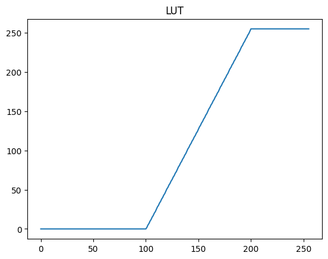

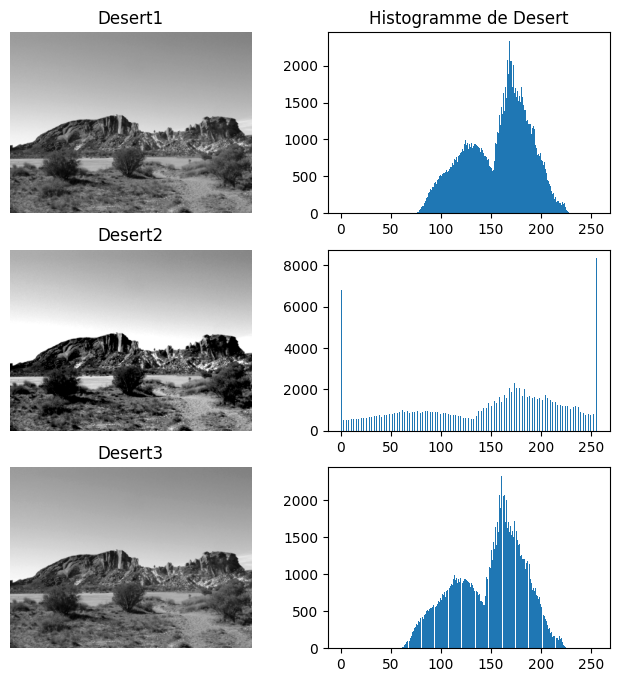

```python
import numpy as np
def LUT(x, min, max):
    if x < min:
        return 0
    elif x > max:
        return 255
    else:
        return int((x - min) / (max - min) * 255)

min_pixel = img.min()  # valeur min des pixels
max_pixel = img.max()  # vleur max des pixels
intervalle = (min_pixel, max_pixel)
print(f"L'intervalle des pixels est : {intervalle}")

def LUT_idealny(x, min_pixel, max_pixel):
    return int((x - min_pixel) / (max_pixel - min_pixel) * 255)

# Verifier que la fonction LUT est bien definie
LUT_x = np.arange(256)
LUT_y = np.array([LUT(x, 100, 200) for x in LUT_x])
fig,ax = plt.subplots()
ax.plot(LUT_x, LUT_y)
ax.set_title('LUT')

fig,ax = plt.subplots(3,2,figsize=(8,8))

# 1) Charger et afficher l'image
img = np.array(plt.imread('desert.bmp'))
ax[0,0].imshow(img)
ax[0,0].set_axis_off()
ax[0,0].set_title('Desert1')

# Afficher l'histogramme
_,_,_ = ax[0,1].hist(img.flatten(),bins=256, width=1,range=(0,256))
ax[0,1].set_title('Histogramme de Desert')


# 2) Transformation avec perte d'information
img_2 = np.array([[LUT(pixel, 100, 200) for pixel in row] for row in img])

ax[1,0].imshow(img_2)
ax[1,0].set_axis_off()
ax[1,0].set_title('Desert2')

_,_,_ = ax[1,1].hist(img_2.flatten(),bins=256, width=1,range=(0,256))
#ax[1,1].set_title('Histogramme de Desert (perte)')

# 3) Transformation sans perte d'information
img_3 = np.array([[LUT_idealny(pixel,min_pixel, max_pixel) for pixel in row] for row in img])

ax[2,0].imshow(img_3)
ax[2,0].set_axis_off()
ax[2,0].set_title('Desert3')

_,_,_ = ax[2,1].hist(img_3.flatten(),bins=256, width=1,range=(0,256))
#ax[2,1].set_title('Histogramme de Desert (sans perte)')
```

# Exercice 5

## Détermination automatique de $p_0$ et $p_1$

Soit $I$ une image de taille $M\times N$.

Soit $s\in[0,100]$ une valeur choisie par l'utilisateur. On choisit $p_0$ (respectivement $p_1$) de telle manière que $s\%$ des pixels de l'image $I$ aient une valeur plus petite que $p_0$ (respectivement plus grande que $p_1$).

Autrement dit, soit $H$ l'histogramme cumulé de $I$, $p_0$ est la plus petite valeur $p$ telle que $\frac{H(p)}{MN} \geq s/100$, et $p_1$ est la plus grande valeur $p$ telle que $\frac{H(p)}{MN} \leq 1 - s/100$.

- Modifiez la cellule ci-dessous pour déterminer $p_0$ et $p_1$.

**Astuce** : pour $p_0$, parcourir l'histogramme cumulé $H$ à partir de la valeur de pixel 0 ; pour $p_1$, parcourir $H$ dans le sens inverse (donc à partir de l'indice 255).

- Testez votre code avec l'image `desert.bmp`, par exemple avec un seuil de 1% :
- Les valeurs de $p_0$ et $p_1$ sont-elles proches de celles que vous avez choisies dans l'exercice précédent ? Essayez avec d'autres valeurs du seuil et affichez les images correspondantes.
- Faites de même pour les images `manoir.bmp` et `fruits.bmp`.

COMENTAIRES: Les valeurs de p0 et p1 sont proches de celles de l'exercice précédent pour les images 'desert' et 'manoir'. En revanche, pour l'image 'fruits', les valeurs sont très éloignées de p0 et p1 de l'exercice précédent.

exo precendent: p0 = 73, p1 = 230 desert: p0 = 87, p1 = 215 manoir: p0= 110, p1= 254 fruits: p0= 0, p1= 55

```
p0= 87
p1= 215
```

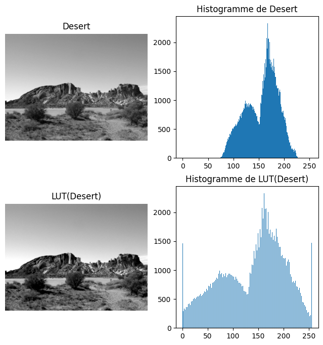

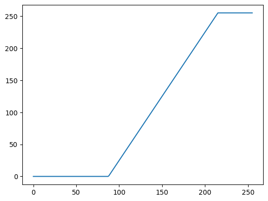

```python
fig,ax = plt.subplots(2,2,figsize=(8,8))
# Charger et afficher l'image
img = np.array(plt.imread('desert.bmp'))
ax[0,0].imshow(img)
ax[0,0].set_axis_off()
ax[0,0].set_title('Desert')

# Calculer l'histogramme: white box (on en aura besoin plus bas)
hist = np.zeros(256)
for i in range(img.shape[0]):
    for j in range(img.shape[1]):
        hist[img[i, j]] = hist[img[i, j]] + 1

# Afficher l'histogramme
ax[0, 1].bar(range(256),hist, width=1,align='center')
ax[0, 1].set_title('Histogramme de Desert')

# Histogramme cumule: méthode 2 (optimisée)
H = np.zeros(256)
H[0] = hist[0]
for i in range(1, 256):
    H[i] = H[i-1] + hist[i]

# Choisir un pourcentage s
s = 1  # (en pourcents (%))

# Trouver p0
nb_pixels = img.shape[0] * img.shape[1]
p0 = 0
while p0 < 256 and H[p0] / nb_pixels < s / 100:
    p0 += 1

# Trouver p1
p1 = 255
while p1 >= 0 and H[p1] / nb_pixels > 1 - s / 100:
    p1 -= 1

# Valeurs
print(f'p0= {p0}')
print(f'p1= {p1}')

# Utiliser la fonction LUT (de utils)
LUT_x = np.arange(256)
LUT_y = np.array([0 if x < p0 else (255 if x > p1 else int((x - p0) / (p1 - p0) * 255)) for x in LUT_x])
plt.figure()
plt.plot(LUT_x, LUT_y)

# Appliquer une LUT a l'image
img_2 = np.array([[LUT_y[pixel] for pixel in row] for row in img])

# Afficher la nouvelle image
ax[1, 0].imshow(img_2)
ax[1, 0].set_axis_off()
ax[1, 0].set_title('LUT(Desert)')

# Afficher le nouvel histogramme
_,_,_ = ax[1, 1].hist(img_2.flatten(), bins=256, width=1,range=(0,256))
ax[1, 1].set_title('Histogramme de LUT(Desert)')
```

# Exercice 6

## Egalisation d'histogramme

Pour une image $I_1(u,v)$ de taille $M\times N$ dont l'histogramme cumulé est $H_1(p)$, l'égalisation d'histogramme consiste à transformer $I_1(u,v)$ en une image $I_2(u,v) = T(I_1(u,v))$ de manière à ce que le nouvel histogramme cumulé $H_2$ soit le plus linéaire possible. Pour cela, on applique la transformation suivante aux pixels de l'image :

$ T(p) = \frac{255}{MN}H_1(p). $

- Dans la cellule ci-dessous, définir une fonction `egalisation` qui calcule la nouvelle valeur `T(p)` puis mettre en oeuvre l'égalisation d'histogramme et la tester sur `fruits.bmp`.
- Commenter les allures de l'histogramme et de l'histogramme cumulé de la nouvelle image par rapport à ceux de l'image originale.
- Commenter l'aspect visuel de la nouvelle image. Que pensez-vous du résultat par rapport à la correction affine ?
- Appliquer une deuxième fois l'égalisation d'histogramme. Qu'observez-vous ? Comment l'expliquer ?
- Que pensez-vous de l'égalisation appliquée à l'image `cellules.bmp` ?

**COMMENTAIRES:**

1. les allures de l'histogramme:

Histogramme original :

- L'histogramme de l'image originale montre une distribution déséquilibrée des intensités de pixels.
- La majorité des pixels sont concentrés dans des plages spécifiques, ce qui explique un contraste limité.

Histogramme cumulé original:

- L'histogramme cumulé de l'image originale est non linéaire. Il monte rapidement dans certaines plages d'intensités où les pixels sont majoritairement concentrés.

Histogramme égalisé :

- L'histogramme égalisé est plus étalé sur toute la plage ([0, 255]). Cela signifie que les intensités sont redistribuées uniformément, améliorant le contraste.

[figure not shown]

```python
fig,ax = plt.subplots(3,2,figsize=(10,10))
# Charger et afficher l'image
img = np.array(plt.imread('cellules.bmp'))
ax[0,0].imshow(img)
ax[0,0].set_axis_off()
ax[0,0].set_title('Fruits')

# Calculer l'histogramme: white box (on en aura besoin plus bas)
hist = np.zeros(256)
for i in range(img.shape[0]):
    for j in range(img.shape[1]):
        hist[img[i, j]] = hist[img[i, j]] + 1

# Afficher l'histogramme
ax[0, 1].bar(range(256), hist, width=1, align='center', color='gray')
ax[0, 1].set_title('Histogramme')

# Histogramme cumule: calcul optimise
H1 = np.zeros(256)
H1[0] = hist[0]
for i in range(1, 256):
    H1[i] = H1[i-1] + hist[i]

# Afficher l'histogramme cumulé
ax[1, 1].plot(range(256), H1, color='blue')
ax[1, 1].set_title('Histogramme CUMULE')

# NB: vous pouvez remplacer les 2 calculs d'hist plus haut par des appels
# à la fonction show_histogram (voir la doc de cette fonction dans utils.py)

# Transformation d'egalisation d'histogramme
def egalisation(p):
    MN = img.size
    return (255 / MN) * H1[p]

# Appliquer l'egalisation d'histogramme
img_2 = copy(img)
for i in range(img_2.shape[0]):
    for j in range(img_2.shape[1]):
        img_2[i, j] = egalisation(img[i, j])

# Afficher la nouvelle image
ax[1,0].imshow(img_2)
ax[1,0].set_axis_off()
ax[1,0].set_title('Nouvelle image')

# Afficher l'histogramme egalise
_,_,_ = ax[2,1].hist(img_2.flatten(), bins=256, width=1,range=(0,256))
ax[2, 1].set_title('Histogramme de egalise')

# Calculer l'histogramme cumulé égalisé
ax[2, 0].hist(img_2.flatten(), bins=256, cumulative=True, density=True, color='blue', histtype='step', range=(0, 256))
ax[2, 0].set_title('Histogramme cumulé égalisé')
```

# Exercice 7

## Segmentation par seuillage

La segmentation d'une image consiste à identifier des classes de pixels suivant certains critères. C'est un domaine de recherche encore très actif dans des domaines tels que l'imagerie médicale (pour segmenter les organes).

Par exemple dans l'image `tomates.bmp`, on constate que le fond est nettement plus sombre que les tomates, et on peut choisir comme critère un seuil d'intensité $s$ : un pixel donné appartient à la classe **fond** si sa valeur est inférieure à $s$, et à la classe **tomate** sinon.

- Visualiser l'histogramme de l'image `tomates.bmp` et identifier une valeur plausible du seuil $s$ qui permette de séparer le fond des tomates.
- Dans la cellule ci-dessous implémenter la fonction `threshold` suivante :

$ T(p) = \left\lbrace \begin{array}{ccc} 255 & \text{si} & p > s,\\ 0 & \text{sinon.} \end{array} \right. $  
Vous pouvez la tester de la façon suivante, en faisant varier le seuil $s$ autour de la valeur que vous avez évaluée précédemment.

- Dans le même esprit que le TP précédent, vous pouvez créer un masque puis utiliser le produit entre deux `numpy.ndarray` pour afficher les tomates sans le fond, ou le fond sans les tomates :
- Il y a un message caché dans le fond de l'image `tomates.bmp` saurez-vous le rendre clairement visible ?

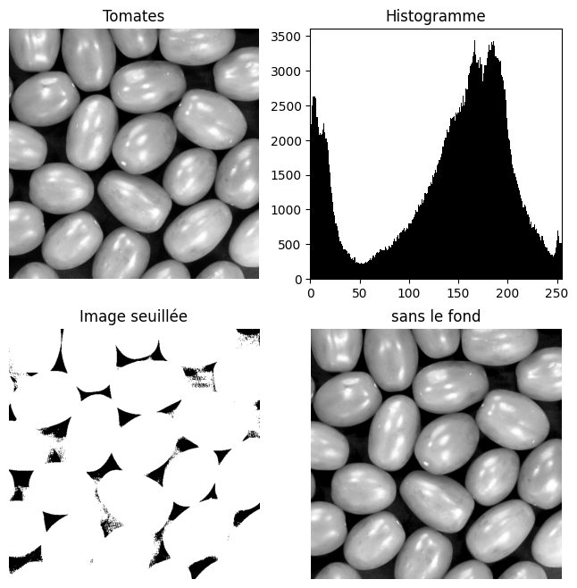

```python
#Exo 7
import copy

img = np.array(plt.imread('tomates.bmp'))

# Création de la figure et des axes
fig, ax = plt.subplots(2, 2, figsize=(8, 8))

# Affichage de l'image d'origine
ax[0, 0].imshow(img, cmap='gray', vmin=0, vmax=255)
ax[0, 0].set_axis_off()
ax[0, 0].set_title('Tomates')

# Calcul de l'histogramme
hist = np.zeros(256)
for i in range(img.shape[0]):
    for j in range(img.shape[1]):
        hist[img[i, j]] += 1

# Fonction d'affichage de l'histogramme
def show_bars(hist, title):
    ax[0, 1].bar(range(256), hist, width=1.0, color='black')
    ax[0, 1].set_title(title)
    ax[0, 1].set_xlim(0, 255)

show_bars(hist, title='Histogramme')

# Fonction de seuillage
def threshold(img, s):
    img_th = copy.deepcopy(img)
    img_th[img_th < s] = 0
    img_th[img_th >= s] = 255
    return img_th

s = 13
img_2 = threshold(img, s)

# Affichage de l'image seuillée
ax[1, 0].imshow(img_2, cmap='gray', vmin=0, vmax=255)
ax[1, 0].set_axis_off()
ax[1, 0].set_title('Image seuillée')

# Affichage des tomates sans le fond (valeurs proches de 255)
img_3 = np.zeros_like(img)
img_3[img_2 == 255] = img[img_2 == 255]

ax[1, 1].imshow(img_3, cmap='gray', vmin=0, vmax=255)
ax[1, 1].set_axis_off()
ax[1, 1].set_title('sans le fond')

# Afficher la figure complète

plt.show()

# Chercher le message caché dans le fond
show_bars(np.histogram(img_3.flatten(), bins=256, range=(0, 256))[0], 'Histogramme')
```